```python
import pandas as pd
from mitreattack.stix20 import MitreAttackData
import spacy
import numpy as np
import networkx as nx
import random
import matplotlib.pyplot as plt
```

# A preliminary analysis of insider threat detection

In this notebook, we explore the idea of using data analysis and feature engineering as a way to flag high priority security risks in the context of detecting insider threats.

## Data context

In the domain of network security, one often automates some sort of intelligent threat detection process -- one that may trigger an alert, or write to a log if some sort of suspicious network activity has been detected in the network. That can range from things like: too many failed log in account attempts from a user, user log-in from unusual location, security software disabled, unusual privilege escalation activities..etcetc. However, networks can get quite busy, and when a threat detection system generates these alerts or logs the sheer volume of information that is generated can be quite high. When the volume of information provided by such a threat detection system is too high, a human security analyst may experience alert fatigue. This may lead to complications when assessing the true threat content of a given alert. The role of a triage model for threat detection is to somehow try to automate the process of determining whether or not some given alerts should be investigated with higher priority than others.

## The data, and the data challenges

In this notebook, we will explore some approaches to this task, using a dataset sourced by the Fields Institute Cyber Connexions program (http://www.fields.utoronto.ca/activities/23-24/cyber-analyst-stream-FT). The data is divided into entities, events and relationships.

- events: Security alerts with timestamps, severity scores, and descriptions
- entities: Users, hosts, files, processes, domains, databases, network connections
- relationships: Links between events and entities (event id -> entity id)

As we can see, the data provided here is not exactly a large data-dump of raw data. There has already been quite a bit of processing, and a mature threat detection model has already provided security alerts with a severity score, descriptions and timestamp information.

However, there is still work to be done. As already mentioned: with the goal of reducing alert fatigue, one wishes to flag certain events as high priority and somehow understand how one might be able to automate this process.

From a data analysis point of view, this task has a variety of interesting challenges. While there are many to name, one can highlight a few central challenges: a lack of labelled data and "ground truth", and large class imbalances. Furthermore, attackers may purposefully attempt to conceal their activity by masquerading as normal network traffic. This may lead to complications in determining features that are fine grained enough to distinguish attacker behavior from "normal behavior".

### So what can be done?

Essentially, the above may be summed up in the following way: what reprieve do we have in the face of noisy unlabeled data, and how can we determine if a given event should be deemed high priority or not? This should sound to you like we need to get our hands dirty and do some more domain-specific and context aware feature engineering.

### Modeling strategy

The MITRE ATT&K framework (https://attack.mitre.org/) is an elaborate attempt to classify or characterize typical behavior exhibited by security attackers. The framework provides a classification of techniques and tactics that an attacker might utilize, and a great deal of insight into how an attacker may deploy a variety of tactics in some sequential order to realize some ultimate goal. This is one of the most important sources of information we can use to better understand our data: security alerts should not always be viewed in isolation, but if the alerts do indeed come from some sort of attacker, then there should be some grouping of sequential alerts that provide a signal associated to the ultimate goal of an attacker.

In this notebook, we will see how we can interpret the provided dataset as graphical data. We can model the relationships between events and entities via a rather large graph with many connected components. Each connected component will represent some sort of cluster of related activity that we can attempt to score. The scoring of a cluster/connected component will be determined by graph-level features of the component (for example, some measure of connectivity) and some extra data like edge-weights ..etc that we can factor in coming from severity scores already provided and information we can source from the MITRE ATT&K framework.

As always, the first step here is to look at what our data looks like..

```python
import json

with open("security_data_assignment.json", "r") as file:
    data = json.load(file)
```

```python
events_df = pd.DataFrame( data['events'] )
relationships_df = pd.DataFrame( data['relationships'])
entities_df = pd.DataFrame( data['entities'] )
```

```python
entities_df
```

|  | id | type | name | properties |
| --- | --- | --- | --- | --- |
| 0 | 64296679-e738-49af-b388-dd40d1d82046 | Host | DC-473 | {'hostname': 'DC-473', 'ip_address': '192.168.... |
| 1 | d8bcd64a-963b-4b05-8703-cbeb4ac1d673 | Host | WS-895 | {'hostname': 'WS-895', 'ip_address': '192.168.... |
| 2 | 1129d5f7-e696-49d1-a563-50130e22c0e7 | User | David Miller | {'username': 'david.miller', 'role': 'User', '... |
| 3 | 9dc2bf0a-4144-48a8-9085-945bd3f5cb69 | User | Maria Brown | {'username': 'maria.brown', 'role': 'Developer... |
| 4 | 705f282b-f4b5-4647-b658-add9a2c7f37a | File | policy78.jar | {'path': 'C:\Users\Downloads', 'name': 'policy... |
| ... | ... | ... | ... | ... |
| 482 | 6d0ed87e-1970-4159-aeaa-5f32d1ecdc0c | Host | WS-758 | {'hostname': 'WS-758', 'ip_address': '192.168.... |
| 483 | 2b85e41d-d023-4b63-8b68-42558b9157c4 | Host | SRV-979 | {'hostname': 'SRV-979', 'ip_address': '192.168... |
| 484 | 4beab54a-6c5c-406f-b86e-28ec58f1ae9e | User | Jane Johnson | {'username': 'jane.johnson1', 'role': 'User', ... |
| 485 | 9b3b2b60-723c-4f35-b468-df9a677458e0 | NetworkConnection | 192.168.168.175:53 -> 192.168.147.50 | {'source_ip': '192.168.168.175', 'dest_ip': '1... |
| 486 | 1360e679-b3bb-4bb7-9f31-2e6c82146806 | Host | WS-534 | {'hostname': 'WS-534', 'ip_address': '192.168.... |

487 rows × 4 columns

```python
events_df
```

|  | id | type | timestamp | severity | description | alert_style | alert_message |
| --- | --- | --- | --- | --- | --- | --- | --- |
| 0 | f8ea18c3-d35b-470c-8067-5748b15e4528 | Authentication | 2026-06-03T19:26:52.210693 | 6 | Login from unusual geographic location | behavioral | BEHAVIOR ANOMALY: Unusual authentication patte... |
| 1 | e838eea3-cbae-420e-a977-646fa08fcaa5 | Defense Evasion | 2026-06-03T23:34:24.430799 | 9 | Security service stopped or disabled | raw_telemetry | Service state change: outlook.exe service stop... |
| 2 | d524c6c0-1141-4217-bd2e-5f7398a082e3 | Privilege Operation | 2026-06-04T01:07:56.239638 | 8 | New user account created with admin privileges | rules_based | ADMIN ACTION ALERT: New user account created w... |
| 3 | 3e054172-7d3e-46c9-9794-a42a06c0fb90 | Data Access | 2026-06-04T02:01:23.071498 | 7 | Configuration files modified | rules_based | FILE ACCESS ALERT: Configuration files modifie... |
| 4 | 7d5cb5fd-8b6b-4a80-8a1a-da8c356b10b3 | Exfiltration | 2026-06-04T03:29:24.171435 | 8 | Encrypted communication to rare domain | raw_telemetry | RAW_TELEMETRY ALERT: Encrypted communication t... |
| ... | ... | ... | ... | ... | ... | ... | ... |
| 352 | 058cf3e0-63f3-4c0f-85a8-45ceee4c9689 | Authentication | 2026-06-02T18:06:17.240032 | 3 | Login from unusual location | behavioral | BEHAVIOR ANOMALY: Unusual authentication patte... |
| 353 | 99cec239-5976-4337-b9a3-d76a2551d8d7 | Authentication | 2026-06-03T06:36:37.971773 | 3 | Login outside business hours | raw_telemetry | RAW_TELEMETRY ALERT: Login outside business ho... |
| 354 | eef691a0-a101-4e92-b247-cee63624ca66 | Data Access | 2026-06-02T14:27:39.751749 | 5 | Database query with excessive results | raw_telemetry | RAW_TELEMETRY ALERT: Database query with exces... |
| 355 | 7b2670be-417c-492b-83c1-80dd96f12ac8 | Exfiltration | 2026-06-03T03:06:20.102611 | 1 | Data transfer during off-hours | raw_telemetry | RAW_TELEMETRY ALERT: Data transfer during off-... |
| 356 | ca31e36e-8153-43a0-9a0e-82b7b3dba7cc | Authentication | 2026-06-02T21:43:52.119469 | 6 | Login outside business hours | behavioral | BEHAVIOR ANOMALY: Unusual authentication patte... |

357 rows × 7 columns

As we can see, these security events are provided with a severity score out of 10, and an alert message.

This dataset already provides a rough mapping of the alert content to the MITRE ATT&K framework. We can use the provided type, or use an NLP processor to produce a more refined label for how the event may fit into the MITRE ATT&K framework.

```python
events_df['type'].unique()
```

```
array(['Authentication', 'Defense Evasion', 'Privilege Operation',
       'Data Access', 'Exfiltration'], dtype=object)
```

Let's compare these types to the attack framework.

```python
mitre_attack_data = MitreAttackData("enterprise-attack.json")

mitre_corpus_dict = {}

mitre_mat =  mitre_attack_data.get_tactics_by_matrix()['Enterprise ATT&CK']

for stage in mitre_mat:
    mitre_corpus_dict[stage['x_mitre_shortname']] = {}
    for item in mitre_attack_data.get_techniques_by_tactic(stage['x_mitre_shortname'], 'enterprise-attack'):

        mitre_corpus_dict[stage['x_mitre_shortname']][item.name] =  item.description
```

```python
from collections import defaultdict

mitre_by_stage = mitre_corpus_dict

ordered_steps = dict ( zip (    mitre_by_stage.keys(), list( range(len( mitre_by_stage.keys() )) )  ) )

def build_mitre_documents(mitre_by_stage: dict[str, list[str]]) -> list[dict]:
    docs = []

    for stage, techniques in mitre_by_stage.items():
        for technique in techniques:
            description = mitre_by_stage[stage][technique]
            docs.append({
                "stage": stage,
                "technique": technique,
                "description":description,
                # This is the text BM25 will search.
                # Including the stage can help when the query has words like "credential" or "execution".
                "text": f"{stage} {technique} {description}",
            })

    return docs

docs = build_mitre_documents(mitre_by_stage)

# for doc in docs[:10]:
#     print(doc)
```

```python
ordered_steps
```

```
{'reconnaissance': 0,
 'resource-development': 1,
 'initial-access': 2,
 'execution': 3,
 'persistence': 4,
 'privilege-escalation': 5,
 'stealth': 6,
 'defense-impairment': 7,
 'credential-access': 8,
 'discovery': 9,
 'lateral-movement': 10,
 'collection': 11,
 'command-and-control': 12,
 'exfiltration': 13,
 'impact': 14}
```

There are pros and cons with having finer alert categories, as we would of course like to have some robustness in how the alerts are defined. Generally speaking, we will be interested in clusters of events that are roughly increasing through the progression of attacker tactics -- but this progression may not always be strictly increasing. For example, an attack chain may look like:

Initial Access (2) -> Privilege-Escalation (5) -> Execution (3) -> Credential-Access (8) -> Initial Access (2) -> Lateral-Movement (10) -> Collection (11) -> Exfiltration (13)

with some drops in the progression, depending on the type of attack strategy being deployed, and if for example the attacker is attempting to penetrate different entities of varying levels of account privileges.

Therefore, to capture the general progression of this chain, we may wish to have coarser categories, so that movement within a coarse category does not necessarily count as a decrease in the progression. Another approach here would be use some ideas from NLP processing and to analyze "skip-grams" -- where a progression sequence 2,5,3,8,2,10,11,13 can be viewed as a "word" , and increasing segments in the progression can be viewed as an "n-gram" but we also want to allow for "n-grams up to some skipped letters" (hence "skip-gram").

BM25s is a great Python library for NLP processing. We use the MITRE framework Python library to create a large corpus of text associated to each tactic and technique, so that the NLP processor can map semantic similarity between the tokens extracted from the MITRE corpus (per tactic) and tokens extracted from text associated to an event (the given alert type, description and alert message). We can also take the top k matches (we'll set k=2 by default) from the NLP matcher.

```python
import bm25s

# Texts to index
corpus_texts = [doc["text"] for doc in docs]

# Tokenize
corpus_tokens = bm25s.tokenize(corpus_texts)

# Create and build retriever
retriever = bm25s.BM25(corpus=docs)
retriever.index(corpus_tokens)
```

```python
def get_top_tactics(query, thres = 0.5, k=2):
    query_tokens = bm25s.tokenize(query)
    results, scores = retriever.retrieve(query_tokens, k)
    return_string = ''
    for doc, score in zip(results[0], scores[0]):
        if return_string != '':
            return_string += '|'
        if score > thres:
            return_string += doc['stage']

    return return_string
```

```python
events_df['nlp_string'] = events_df['type'] + ' ' + events_df['description'] + ' ' + events_df['alert_message']
events_df['MITRE_framework_tactic'] =  events_df['nlp_string'].apply( lambda x : get_top_tactics(x) )
```

```python
ordered_steps = dict ( zip (    mitre_by_stage.keys(), list( range(len( mitre_by_stage.keys() )) )  ) )
```

```python
events_df[['type', 'MITRE_framework_tactic']]
```

|  | type | MITRE_framework_tactic |
| --- | --- | --- |
| 0 | Authentication | stealth\|stealth |
| 1 | Defense Evasion | defense-impairment\|stealth |
| 2 | Privilege Operation | privilege-escalation\|persistence |
| 3 | Data Access | collection\|credential-access |
| 4 | Exfiltration | exfiltration\|credential-access |
| ... | ... | ... |
| 352 | Authentication | stealth\|privilege-escalation |
| 353 | Authentication | reconnaissance\|credential-access |
| 354 | Data Access | impact\|privilege-escalation |
| 355 | Exfiltration | exfiltration\|exfiltration |
| 356 | Authentication | reconnaissance\|credential-access |

357 rows × 2 columns

Here we can see that the provided type from the dataset roughly lines up with the matched MITRE tactic. Also, keep in mind that this data comes from the context of insider threat -- so "recon" or "authentication" may have a different connotation (i.e. attacker does not need to necessarily find access into the system as an outsider). Generally, one should look at the tactic sequence in the MITRE framework as being a little shifted forward to the right in the context of insider threat.

In summary: If we were dealing with data that does not already provide a type, we can use this type of NLP processing. We can also refine our analysis of the progression through the MITRE framework using NLP processing. For now, we can work with the provided alert type and see if it makes much of a difference here.

Using networkx, we can encode the data in the form of a graph. It is naturally a bipartite graph, although this structure will ultimately not really be needed for this preliminary analysis.

```python
## If we choose to use the NLP processor to determine the threat stages, we can use this cell instead...

# events_df['MITRE_step_max'] = events_df['MITRE_framework_tactic'].apply( lambda x :  max( ordered_steps[get_top_tactics(x).split('|')[0]], ordered_steps[get_top_tactics(x).split('|')[1]] ) )
# events_df['threat_stage'] = pd.cut(  events_df['MITRE_step_max'] ,   [0,4,9, 12, 15] , ordered=True,right=False , labels=[0,1,2,3])
```

```python
events_df['threat_stage'] = events_df['type'].apply( lambda x: ['Authentication', 'Defense Evasion', 'Privilege Operation',
       'Data Access', 'Exfiltration'].index( x ) )
```

```python
data_graph  = nx.Graph()

data_graph.add_nodes_from(  events_df['id'].values , bipartite = 0 )
data_graph.add_nodes_from(  entities_df['id'].values , bipartite = 1 )

zipped_edges = zip( relationships_df['source'].values, relationships_df['target'].values , relationships_df['weight'])
data_graph.add_weighted_edges_from( zipped_edges )
```

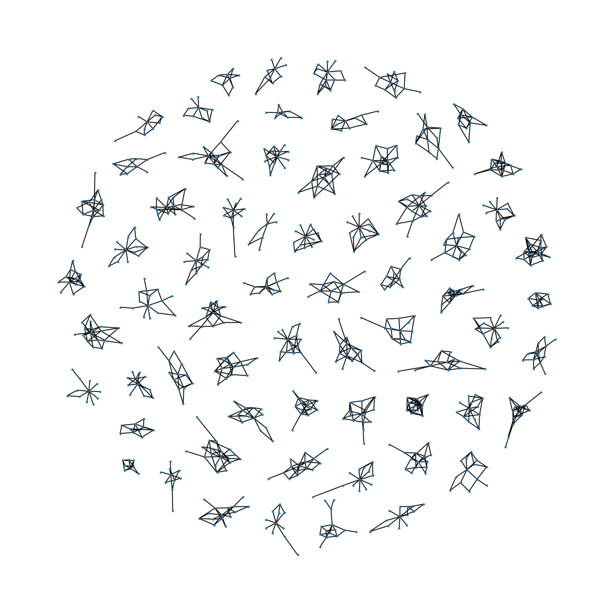

```python
plt.figure(figsize=(10, 10))

nx.draw( data_graph, node_size = 3)

plt.show()
```

Here, we can see that the graph representation of our alert data is highly disconnected with many components. These clusters represent some collection of related events and entities.

We specify a fixed ordering for the connected components of this graph, which specifies a "subgraph id" for each of these clusters. We might as well order by the number of nodes present in such a cluster.

```python
components = sorted ( list( nx.connected_components( data_graph ) ), key = len  )
```

Our first graph-level feature now that we can add to our data is the adjacency degree in the data graph of a given node.

```python
entities_df['adj_degree'] = entities_df['id'].apply( lambda x : data_graph.degree[x] )
events_df['adj_degree'] = events_df['id'].apply( lambda x : data_graph.degree[x] )
```

```python
data_subgraphs = components

subgraph_dict = {}

for idx, subgraph_nodes in enumerate( data_subgraphs ):
    for node in subgraph_nodes:
        subgraph_dict[node] = idx

events_df['subgraph_id'] = events_df['id'].apply( lambda x : subgraph_dict[x] )

subgraph_grper = events_df.groupby( by = 'subgraph_id')
```

Of course, there are more nuanced ways we can weigh these edges and encode the threat progression, but as a simpler model we will see how this turns out.

```python
def construct_event_graph( data_graph, events_df , threat_progress = True ):

    event_ids = events_df['id'].unique()
    event_graph = nx.DiGraph( )

    event_graph.add_nodes_from(event_ids)

    for event in event_ids:

        adj_events =  nx.descendants_at_distance( data_graph, event , 2)
        for adj_event in adj_events:
            if (events_df.loc[events_df['id'] == adj_event ]['timestamp'].values[0] > events_df.loc[events_df['id'] == event]['timestamp'].values[0] ):

                if threat_progress:
                    if (events_df.loc[events_df['id'] == adj_event]['threat_stage'].values[0] > events_df.loc[events_df['id'] == event]['threat_stage'].values[0] ) or (  events_df.loc[events_df['id'] == adj_event]['threat_stage'].values[0] == 5 and events_df.loc[events_df['id'] == event]['threat_stage'].values[0] == 5  ):
                            event_graph.add_edge(event, adj_event, weight= max( events_df.loc[events_df['id']== event ]['severity'].values[0], events_df.loc[events_df['id'] == adj_event]['severity'].values[0]  ))

                else:
                    event_graph.add_edge(event, adj_event, weight= max( events_df.loc[events_df[event]]['severity'].values[0], events_df.loc[events_df[adj_event]]['severity'].values[0]  ))


    return event_graph
```

Before we discuss the matter of scoring a component, let's take a look at one of these clusters. Cluster 22 is shown below, where entity nodes that are either users or hosts are highlighted in red. Event nodes are colored green

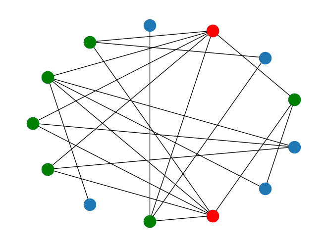

```python
pos= nx.shell_layout(  data_graph.subgraph( components[22] ))
nx.draw( data_graph.subgraph( components[22] ) , pos=pos )
nx.draw_networkx_nodes( data_graph.subgraph( ['80012386-1254-4ba7-bc52-bbc12f405bba', '34d42183-c5ff-45de-9750-9f86faec0612'] ) ,pos=pos, node_color='red' )
nx.draw_networkx_nodes( subgraph_grper.get_group(22)['id'].values , pos=pos,  node_color= 'green')
# nx.draw_networkx_nodes( subgraph_grper.get_group(22)['id'].values , pos=pos,  node_color= 'green')
```

We see here that this activity is highly connected: we have a single user or host that is involved with every event alert for this cluster. This is a sign that there many be a single entity deliberately acting in a way that is triggering these event alerts, rather than having noisier alerts coming from just a large variety of traffic from many users and hosts. We will incorporate this into our scoring system.

```python
def score_eventsubgraph( subgraph_id):
    ## 0.7/0.3 user/host


    component = components[subgraph_id]
    subgraph = construct_event_graph( data_graph.subgraph( components[subgraph_id] ), subgraph_grper.get_group(subgraph_id) )

    user_entities = entities_df[ entities_df['id'].isin( component ) & ( entities_df['type'] == 'User')]
    host_entities = entities_df[ entities_df['id'].isin( component ) & (  entities_df['type'] == 'Host')]

    entity_score = 0.7 * ( user_entities['adj_degree'].max()/subgraph.number_of_nodes() ) + 0.3*( host_entities['adj_degree'].max()/subgraph.number_of_nodes() )
    if np.isnan(entity_score):
        entity_score = 0

    edge_score = subgraph.size( weight='weight') * nx.density(subgraph)
    if np.isnan(edge_score):
        edge_score = 0


    return entity_score + edge_score
```

The final score of a component/cluster is given by the sum of all the weights in the event level digraph for that component, scaled by the density of the digraph (i.e. how sparse the graph is , or how far it is from being a maximality connected digraph) plus a weighted "entity score".

The entity score comes from either a user contribution, or a host contribution. The user/host score is calculated by taking the maximum number of connections per user or host, normalized by the number of events present in the graph.

We choose a weighting of the entity score by taking

$$ \text{entity score} = 0.7 \cdot (\text{user score}) + (0.3)\cdot (\text{host score}) $$

of course, these weights can be optimized...

```python
eventsubgraphs_df = pd.DataFrame()
eventsubgraphs_df['id'] =  pd.Series( range(len(components)) )
```

```python
eventsubgraphs_df['density'] = eventsubgraphs_df['id'].apply( lambda x : nx.density(construct_event_graph( data_graph.subgraph( components[x] ), subgraph_grper.get_group(x) ) ) )
eventsubgraphs_df['edges'] = eventsubgraphs_df['id'].apply( lambda x : nx.number_of_edges(construct_event_graph( data_graph.subgraph( components[x] ), subgraph_grper.get_group(x) ) ) )
eventsubgraphs_df['nodes'] = eventsubgraphs_df['id'].apply( lambda x : nx.number_of_nodes(construct_event_graph( data_graph.subgraph( components[x] ), subgraph_grper.get_group(x) ) ) )
```

```python
eventsubgraphs_df['score'] = eventsubgraphs_df['id'].apply( lambda x : score_eventsubgraph(x)  )
```

```python
eventsubgraphs_df['score'].describe()
```

```
count    65.000000
mean      4.158485
std       9.846511
min       0.000000
25%       0.666667
50%       1.000000
75%       2.575000
max      47.800000
Name: score, dtype: float64
```

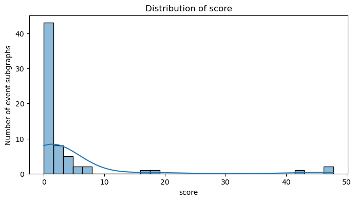

```python
import matplotlib.pyplot as plt
import seaborn as sns


plt.figure(figsize=(8, 4))
sns.histplot(eventsubgraphs_df['score'].dropna(), bins=30, kde=True)
plt.title(f"Distribution of score")
plt.xlabel('score')
plt.ylabel("Number of event subgraphs")
plt.show()
```

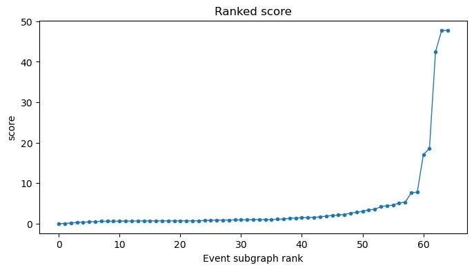

```python
scores = eventsubgraphs_df['score'].dropna().sort_values(ascending=True).reset_index(drop=True)

plt.figure(figsize=(8, 4))
plt.plot(scores.values, marker="o", linewidth=1, markersize=3)
plt.title(f"Ranked score")
plt.xlabel("Event subgraph rank")
plt.ylabel('score')
plt.show()
```

As we can see here, our method of scoring has done a pretty good job at distinguishing 3 out of 65 high risk clusters of events -- where our original event dataset consisted of 357 entries.

In fact, there also seems to be a separation a three way separation of clusters here: a high priority class (score >= 40), a medium class (score between 10 and 40), and a lower priority class (score <= 10).

Now, we just simply bin our scores by these gaps, and this will define our low, medium , high priority alert tags

```python
scores = eventsubgraphs_df['score'].dropna().sort_values()
values = scores.values

# Differences between adjacent sorted scores
gaps = np.diff(values)

# Indices of the 2 largest gaps
gap_idxs = np.argsort(gaps)[-2:]
gap_idxs = np.sort(gap_idxs)

# Thresholds halfway between the separated groups
thresholds = [
    (values[i] + values[i + 1]) / 2
    for i in gap_idxs
]

thresholds
```

```
[np.float64(12.416607142857144), np.float64(30.542857142857144)]
```

```python
eventsubgraphs_df["priority_bin"] = pd.cut(
    eventsubgraphs_df['score'],
    bins=[-np.inf, thresholds[0], thresholds[1], np.inf],
    labels=["low", "medium", "high"]
)
```

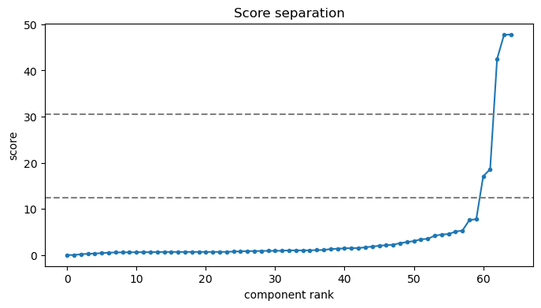

```python
ranked = eventsubgraphs_df['score'].dropna().sort_values().reset_index(drop=True)

plt.figure(figsize=(8, 4))
plt.plot(ranked.values, marker="o", markersize=3)

for t in thresholds:
    plt.axhline(t, linestyle="--", color="grey")

plt.title("Score separation")
plt.xlabel("component rank")
plt.ylabel('score')
plt.show()
```

## Final thoughts

Let's take a look at some of the event level digraphs, from different priority classes.

```python
eventsubgraphs_df[['id', 'score', 'priority_bin']]
```

|  | id | score | priority_bin |
| --- | --- | --- | --- |
| 0 | 0 | 0.000000 | low |
| 1 | 1 | 0.900000 | low |
| 2 | 2 | 1.000000 | low |
| 3 | 3 | 0.000000 | low |
| 4 | 4 | 1.008333 | low |
| ... | ... | ... | ... |
| 60 | 60 | 4.538095 | low |
| 61 | 61 | 0.410714 | low |
| 62 | 62 | 18.585714 | medium |
| 63 | 63 | 0.662500 | low |
| 64 | 64 | 4.176786 | low |

65 rows × 3 columns

We only have 3 components (21,22 and 39) in the high priority class, so let's look at them all...

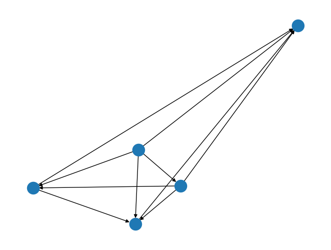

```python
nx.draw( construct_event_graph( data_graph.subgraph( components[21] ), subgraph_grper.get_group(21) ))
```

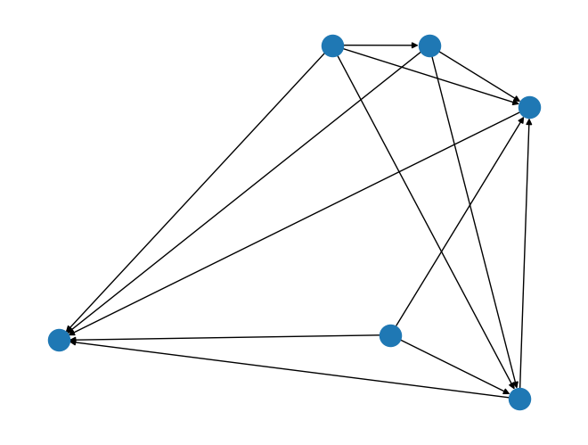

```python
nx.draw( construct_event_graph( data_graph.subgraph( components[22] ), subgraph_grper.get_group(22) ))
```

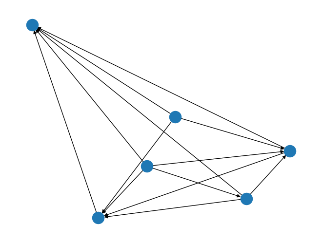

```python
nx.draw( construct_event_graph( data_graph.subgraph( components[39] ), subgraph_grper.get_group(39) ) )
```

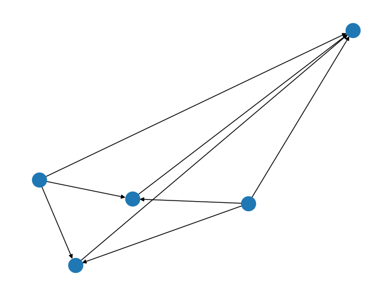

```python
nx.draw( construct_event_graph( data_graph.subgraph( components[9] ), subgraph_grper.get_group(9) ))
```

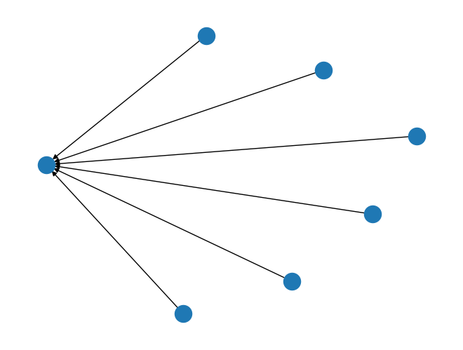

```python
nx.draw( construct_event_graph( data_graph.subgraph( components[42] ), subgraph_grper.get_group(42) ))
```

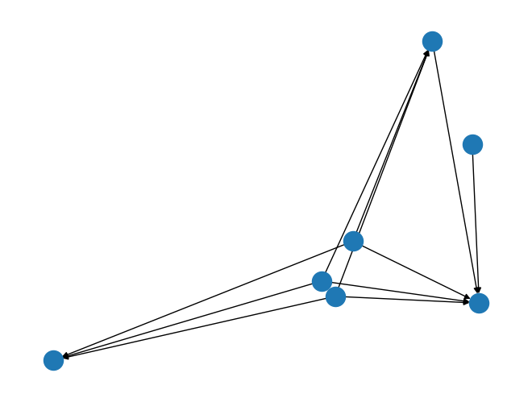

```python
nx.draw( construct_event_graph( data_graph.subgraph( components[62] ), subgraph_grper.get_group(62) ))
```

And some low priority components...

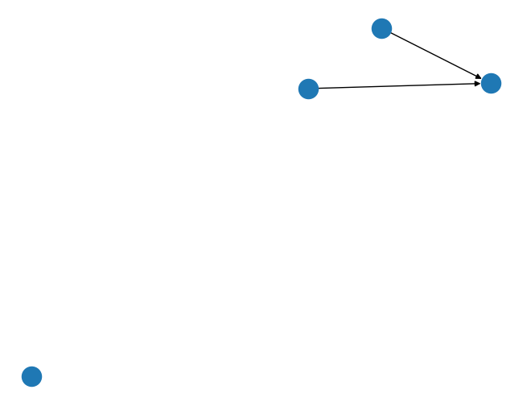

```python
nx.draw( construct_event_graph( data_graph.subgraph( components[46] ), subgraph_grper.get_group(46) ))
```

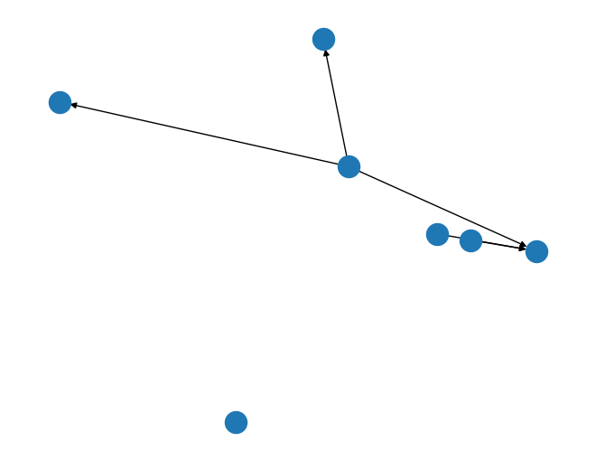

```python
nx.draw( construct_event_graph( data_graph.subgraph( components[60] ), subgraph_grper.get_group(60) ))
```

An interesting question is if there there might be graph motifs that are typically associated to high priorty risk clusters of events. If we had access to more labeled data, one might wonder if one can attempt to automate this procedure by graph deep learning on graphical representations of event data.

There are also many non-deep learning avenues one can explore that can refine the rough idea presented here. We can optimize the scoring system, and how we model the event progression through the MITRE framework (as already mentioned). Some more potential avenues here might relate to incorporating more interesting graph-level features: graph centrality, graph communicability (https://networkx.org/documentation/stable/reference/algorithms/generated/networkx.algorithms.communicability_alg.communicability.html), and some other kinds of "message-passaging" modeling one can analyze on a given graph. However, at the end of the day, the general idea is clear: we can understand this kind of data by leveraging the natural graph type structure the data has, and via this graph structure we can have potentially engineer more sophisticated features.